# Causal Effects in Nonexperimental Studies

January, 2021

## At a glance

## Overview

- Not always possible to set up a randomized control trial (RCT) – costly
- Question: can we reproduce causal effect estimates obtained through a randomized control trial - the gold standard - using data from nonexperimental studies? Enter: propensity scores
- Methodology paper:
  - Show that applying propensity scores to LaLonde (1986)’s nonexperimental data can mitigate these concerns
  - Estimates are not sensitive to the specification of the estimated propensity score, but are sensitive to the assumption of selection on observable

## Data and methodology

## The RCT

NSW – federally funded support program in the 1970s providing opportunities for work experience to unemployed, economically struggling individuals

- Treatment randomly assigned (\(N_1=297\)) among those eligible (\(N=722\))
  - But randomization over a period of two years – *cohort phenomenom*: change in characteristics of individuals within treatment group
- Dehejia and Wahba (1999) further limit themselves to individuals that entered early enough (important to look at several years of preintervention earnings)

## Nonexperimental comparison

- Panel Study of Income Dynamics
- Current Population Survey

Both differ dramatically from the treatment group in terms of age, marital status, ethnicity, and preintervention earning, only small adjustments made in LaLonde (1986)

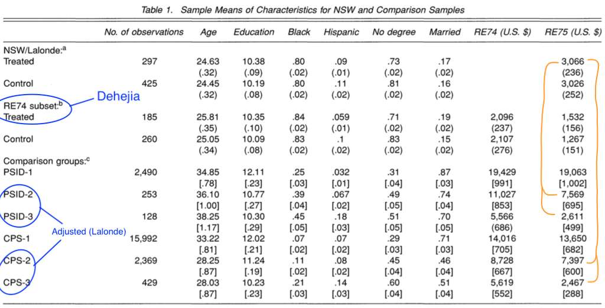

## Lalonde approach

## Lalondes’s main findings

- LaLonde (1986) finds large differences between RCT and nonexperimental estimates:

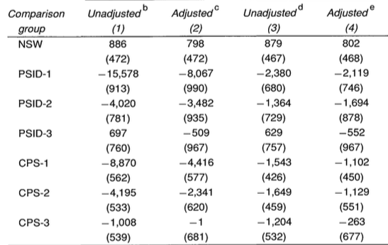

- Concluded that existing econometric techniques could not produce unbiased estimates

## Subsample in Dehejia and Wahba (1999)

## Incorporating propensity scores

## Recap: propensity scores

- Probability of assignment to treatment, conditional on covariates
- comparability of the treatment and nonexperimental comparison groups in terms of preintervention variables

## Results

## Sensitivity analysis

## Concluding remarks

Dehejia, Rajeev H, and Sadek Wahba. 1999. “Causal Effects in Nonexperimental Studies: Reevaluating the Evaluation of Training Programs.” *Journal of the American Statistical Association* 94 (448): 1053–62.

LaLonde, Robert J. 1986. “Evaluating the Econometric Evaluations of Training Programs with Experimental Data.” *The American Economic Review*, 604–20.